# Análisis de datos ómicos PEC 1

## Gráfico de distribición de los datos según 7 biomarcadores. Media t-student.

Creatina

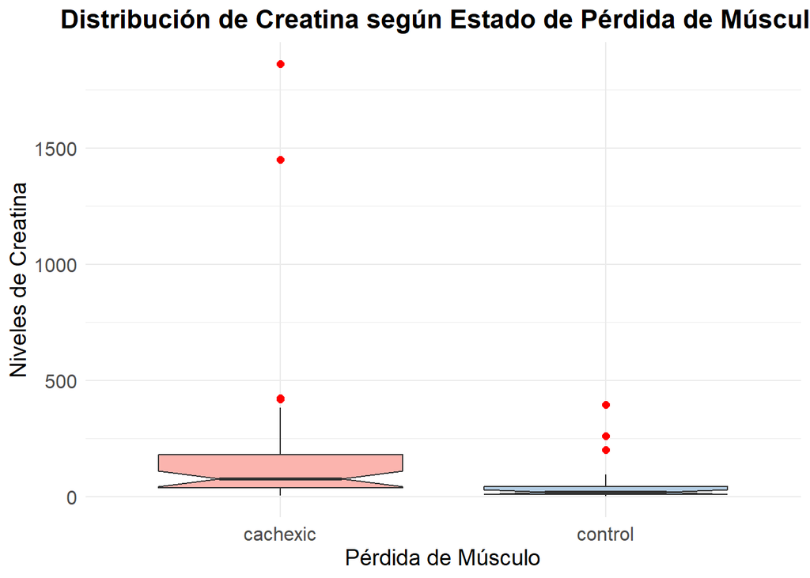

```r
ggplot(datos, aes(x = Muscle.loss, y = Creatine, fill = Muscle.loss)) +
  geom_boxplot(outlier.colour = "red", outlier.shape = 16, outlier.size = 2,
               notch = TRUE) +
  scale_fill_brewer(palette = "Pastel1") +
  labs(title = "Distribución de Creatina según Estado de Pérdida de Músculo",
       x = "Pérdida de Músculo",
       y = "Niveles de Creatina") +
  theme_minimal() +
  theme(
    plot.title = element_text(hjust = 0.5, size = 16, face = "bold"),
    axis.title.x = element_text(size = 14),
    axis.title.y = element_text(size = 14),
    axis.text = element_text(size = 12),
    legend.position = "none"
  )
```

```r
t_test_result <- t.test(datos$Creatine ~ datos$Muscle.loss)
print(t_test_result)
```

```
##
##  Welch Two Sample t-test
##
## data:  datos$Creatine by datos$Muscle.loss
## t = 2.3988, df = 55.284, p-value = 0.01985
## alternative hypothesis: true difference in means between group cachexic and group control is not equal to 0
## 95 percent confidence interval:
##   20.3217 226.4964
## sample estimates:
## mean in group cachexic  mean in group control
##              174.91340               51.50433
```

Creatinina

```
## Notch went outside hinges
## ℹ Do you want `notch = FALSE`?
```

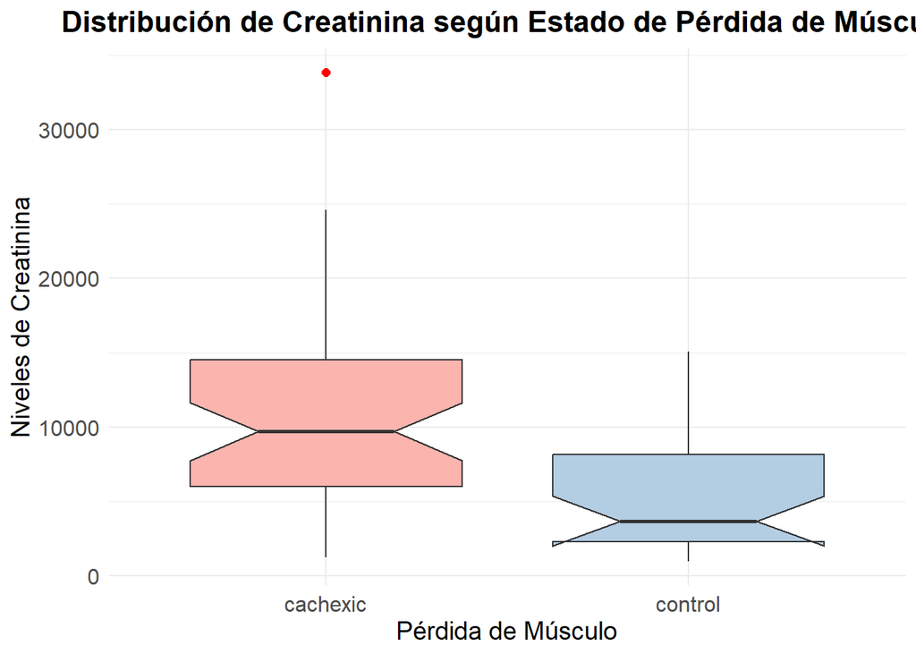

```r
ggplot(datos, aes(x = Muscle.loss, y = Creatinine, fill = Muscle.loss)) +
  geom_boxplot(outlier.colour = "red", outlier.shape = 16, outlier.size = 2,
               notch = TRUE) +
  scale_fill_brewer(palette = "Pastel1") +
  labs(title = "Distribución de Creatinina según Estado de Pérdida de Músculo",
       x = "Pérdida de Músculo",
       y = "Niveles de Creatinina") +
  theme_minimal() +
  theme(
    plot.title = element_text(hjust = 0.5, size = 16, face = "bold"),
    axis.title.x = element_text(size = 14),
    axis.title.y = element_text(size = 14),
    axis.text = element_text(size = 12),
    legend.position = "none"
  )
```

```r
t_test_result <- t.test(datos$Creatinine ~ datos$Muscle.loss)
print(t_test_result)
```

```
##
##  Welch Two Sample t-test
##
## data:  datos$Creatinine by datos$Muscle.loss
## t = 4.0209, df = 74.913, p-value = 0.000137
## alternative hypothesis: true difference in means between group cachexic and group control is not equal to 0
## 95 percent confidence interval:
##  2574.716 7631.216
## sample estimates:
## mean in group cachexic  mean in group control
##              10722.140               5619.175
```

X3.Hydroxybutyrate

```
## Notch went outside hinges
## ℹ Do you want `notch = FALSE`?
```

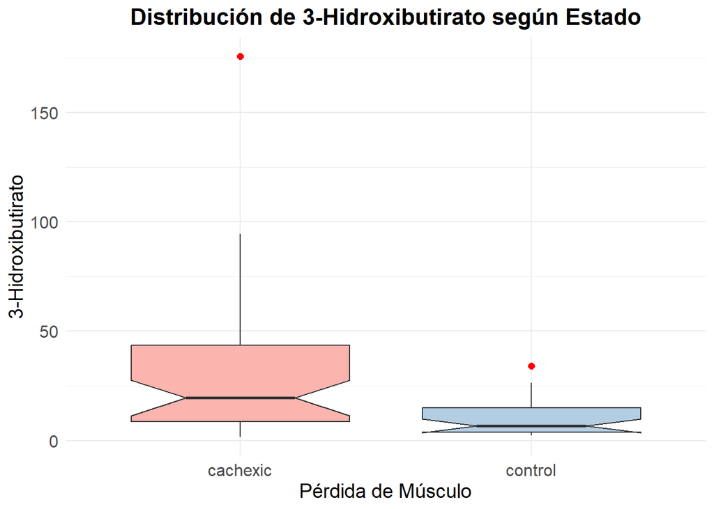

```r
ggplot(datos, aes(x = Muscle.loss, y = X3.Hydroxybutyrate, fill = Muscle.loss)) +
  geom_boxplot(outlier.colour = "red", outlier.shape = 16, outlier.size = 2,
               notch = TRUE) +
  scale_fill_brewer(palette = "Pastel1") +
  labs(title = "Distribución de 3-Hidroxibutirato según Estado",
       x = "Pérdida de Músculo", y = "3-Hidroxibutirato") +
  theme_minimal() +
  theme(
    plot.title = element_text(hjust = 0.5, size = 16, face = "bold"),
    axis.title.x = element_text(size = 14),
    axis.title.y = element_text(size = 14),
    axis.text = element_text(size = 12),
    legend.position = "none"
  )
```

```r
t_test_result <- t.test(datos$X3.Hydroxybutyrate ~ datos$Muscle.loss)
print(t_test_result)
```

```
##
##  Welch Two Sample t-test
##
## data:  datos$X3.Hydroxybutyrate by datos$Muscle.loss
## t = 4.1072, df = 55.263, p-value = 0.0001335
## alternative hypothesis: true difference in means between group cachexic and group control is not equal to 0
## 95 percent confidence interval:
##   9.91565 28.80829
## sample estimates:
## mean in group cachexic  mean in group control
##              29.260638               9.898667
```

Acetona

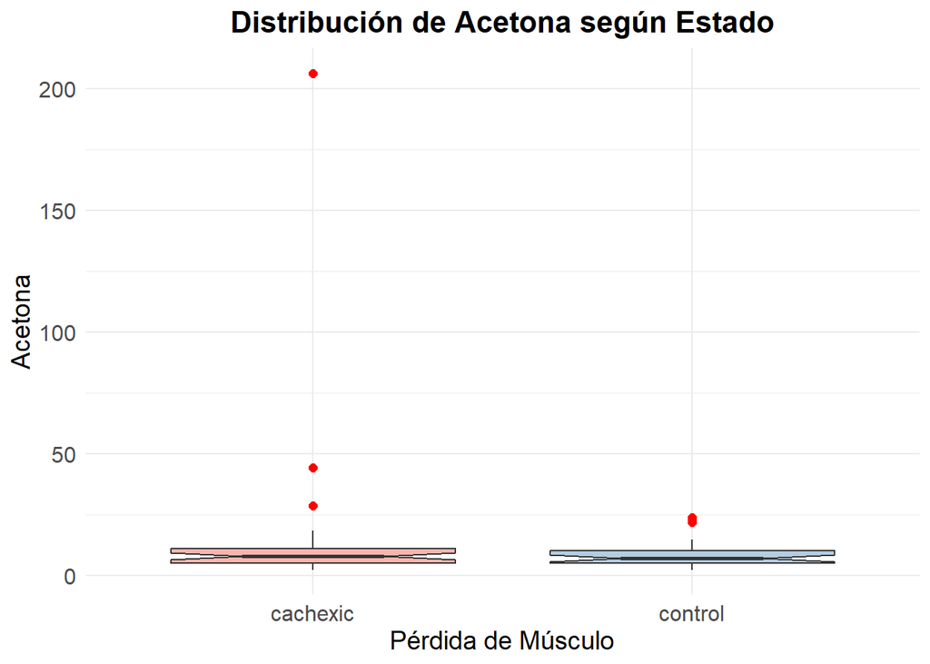

```r
ggplot(datos, aes(x = Muscle.loss, y = Acetone, fill = Muscle.loss)) +
  geom_boxplot(outlier.colour = "red", outlier.shape = 16, outlier.size = 2,
               notch = TRUE) +
  scale_fill_brewer(palette = "Pastel1") +
  labs(title = "Distribución de Acetona según Estado",
       x = "Pérdida de Músculo", y = "Acetona") +
  theme_minimal() +
  theme(
    plot.title = element_text(hjust = 0.5, size = 16, face = "bold"),
    axis.title.x = element_text(size = 14),
    axis.title.y = element_text(size = 14),
    axis.text = element_text(size = 12),
    legend.position = "none"
  )
```

```r
t_test_result <- t.test(datos$Acetone ~ datos$Muscle.loss)
print(t_test_result)
```

```
##
##  Welch Two Sample t-test
##
## data:  datos$Acetone by datos$Muscle.loss
## t = 1.1077, df = 51.123, p-value = 0.2732
## alternative hypothesis: true difference in means between group cachexic and group control is not equal to 0
## 95 percent confidence interval:
##  -4.001479 13.854245
## sample estimates:
## mean in group cachexic  mean in group control
##               13.34638                8.42000
```

Carnitina

```
## Notch went outside hinges
## ℹ Do you want `notch = FALSE`?
## Notch went outside hinges
## ℹ Do you want `notch = FALSE`?
```

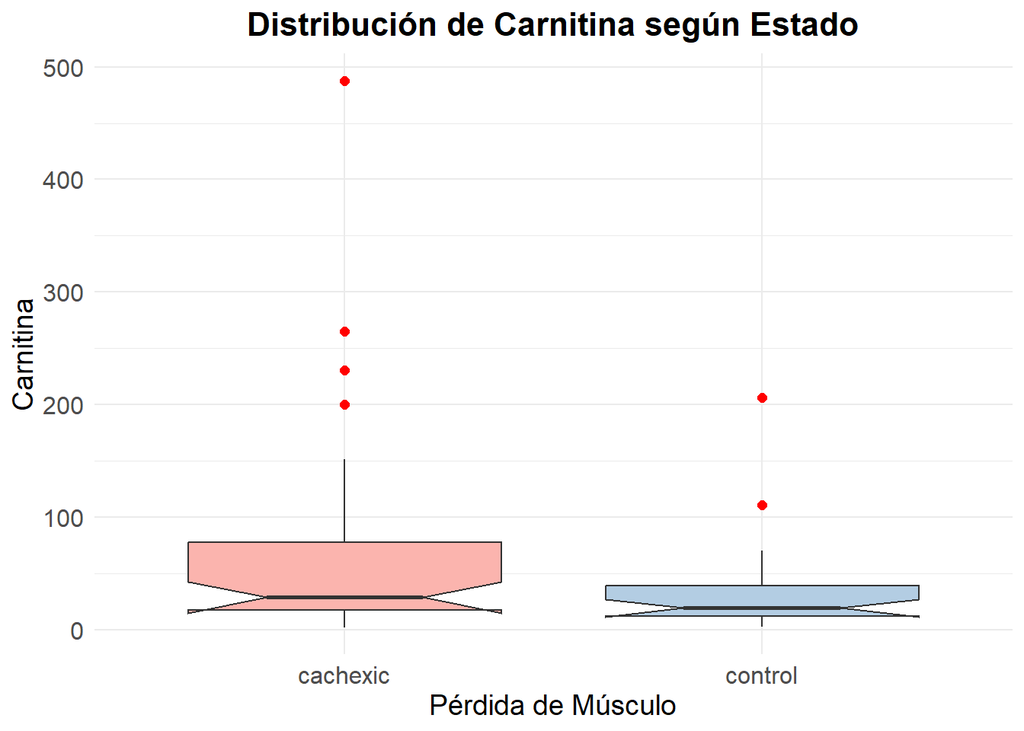

```r
ggplot(datos, aes(x = Muscle.loss, y = Carnitine, fill = Muscle.loss)) +
  geom_boxplot(outlier.colour = "red", outlier.shape = 16, outlier.size = 2,
               notch = TRUE) +
  scale_fill_brewer(palette = "Pastel1") +
  labs(title = "Distribución de Carnitina según Estado",
       x = "Pérdida de Músculo", y = "Carnitina") +
  theme_minimal() +
  theme(
    plot.title = element_text(hjust = 0.5, size = 16, face = "bold"),
    axis.title.x = element_text(size = 14),
    axis.title.y = element_text(size = 14),
    axis.text = element_text(size = 12),
    legend.position = "none"
  )
```

```r
t_test_result <- t.test(datos$Carnitine ~ datos$Muscle.loss)
print(t_test_result)
```

```
##
##  Welch Two Sample t-test
##
## data:  datos$Carnitine by datos$Muscle.loss
## t = 2.1893, df = 69.708, p-value = 0.03193
## alternative hypothesis: true difference in means between group cachexic and group control is not equal to 0
## 95 percent confidence interval:
##   2.862026 61.494896
## sample estimates:
## mean in group cachexic  mean in group control
##               64.62213               32.44367
```

Citrato

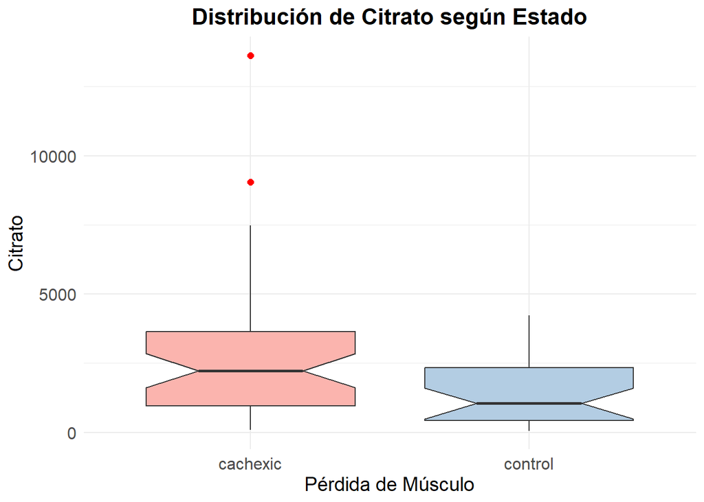

```r
ggplot(datos, aes(x = Muscle.loss, y = Citrate, fill = Muscle.loss)) +
  geom_boxplot(outlier.colour = "red", outlier.shape = 16, outlier.size = 2,
               notch = TRUE) +
  scale_fill_brewer(palette = "Pastel1") +
  labs(title = "Distribución de Citrato según Estado",
       x = "Pérdida de Músculo", y = "Citrato") +
  theme_minimal() +
  theme(
    plot.title = element_text(hjust = 0.5, size = 16, face = "bold"),
    axis.title.x = element_text(size = 14),
    axis.title.y = element_text(size = 14),
    axis.text = element_text(size = 12),
    legend.position = "none"
  )
```

```r
t_test_result <- t.test(datos$Citrate ~ datos$Muscle.loss)
print(t_test_result)
```

```
##
##  Welch Two Sample t-test
##
## data:  datos$Citrate by datos$Muscle.loss
## t = 2.8879, df = 73.123, p-value = 0.005099
## alternative hypothesis: true difference in means between group cachexic and group control is not equal to 0
## 95 percent confidence interval:
##   386.1651 2106.1031
## sample estimates:
## mean in group cachexic  mean in group control
##               2720.853               1474.719
```

Lactato

```
## Notch went outside hinges
## ℹ Do you want `notch = FALSE`?
```

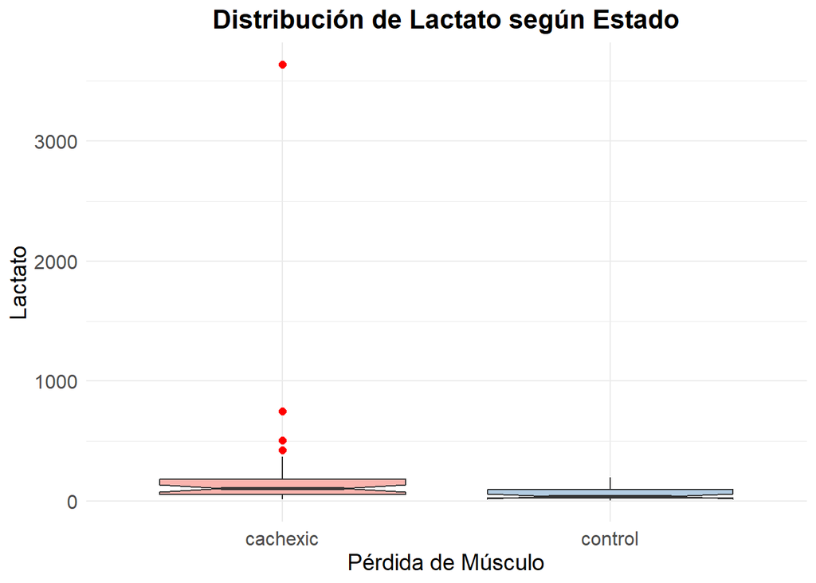

```r
ggplot(datos, aes(x = Muscle.loss, y = Lactate, fill = Muscle.loss)) +
  geom_boxplot(outlier.colour = "red", outlier.shape = 16, outlier.size = 2,
               notch = TRUE) +
  scale_fill_brewer(palette = "Pastel1") +
  labs(title = "Distribución de Lactato según Estado",
       x = "Pérdida de Músculo", y = "Lactato") +
  theme_minimal() +
  theme(
    plot.title = element_text(hjust = 0.5, size = 16, face = "bold"),
    axis.title.x = element_text(size = 14),
    axis.title.y = element_text(size = 14),
    axis.text = element_text(size = 12),
    legend.position = "none"
  )
```

```r
t_test_result <- t.test(datos$Lactate ~ datos$Muscle.loss)
print(t_test_result)
```

```
##
##  Welch Two Sample t-test
##
## data:  datos$Lactate by datos$Muscle.loss
## t = 1.948, df = 47.59, p-value = 0.05733
## alternative hypothesis: true difference in means between group cachexic and group control is not equal to 0
## 95 percent confidence interval:
##   -4.92217 308.68933
## sample estimates:
## mean in group cachexic  mean in group control
##              217.63191               65.74833
```

## Análisis de los datos seleccionados

Acotación de los datos

```r
datos_estudio <- datos %>%
  select(Muscle.loss, 9, 14, 19, 20, 21, 22, 37)

head(datos_estudio)
```

|  | Muscle.loss | X3.Hydroxybutyrate | Acetone | Carnitine | Citrate | Creatine | Creatinine | Lactate |
| --- | --- | --- | --- | --- | --- | --- | --- | --- |
| PIF_178 | cachexic | 56.83 | 9.49 | 265.07 | 3714.50 | 196.37 | 16481.60 | 106.70 |
| PIF_087 | cachexic | 43.82 | 11.82 | 120.30 | 2617.57 | 212.72 | 15835.35 | 368.71 |
| PIF_090 | cachexic | 5.64 | 4.44 | 25.03 | 862.64 | 221.41 | 24587.66 | 749.95 |
| NETL_005_V1 | cachexic | 175.91 | 206.44 | 200.34 | 13629.61 | 85.63 | 20952.22 | 368.71 |
| PIF_115 | cachexic | 76.71 | 44.26 | 84.77 | 854.06 | 105.64 | 6768.26 | 3640.95 |
| PIF_110 | cachexic | 31.82 | 14.44 | 40.04 | 1958.63 | 200.34 | 15677.78 | 113.30 |

Visualización de los datos

```
##        Muscle.loss X3.Hydroxybutyrate            Acetone          Carnitine
##                0.7                0.7                0.7                0.7
##            Citrate           Creatine         Creatinine            Lactate
##                0.7                0.7                0.7                0.7
```

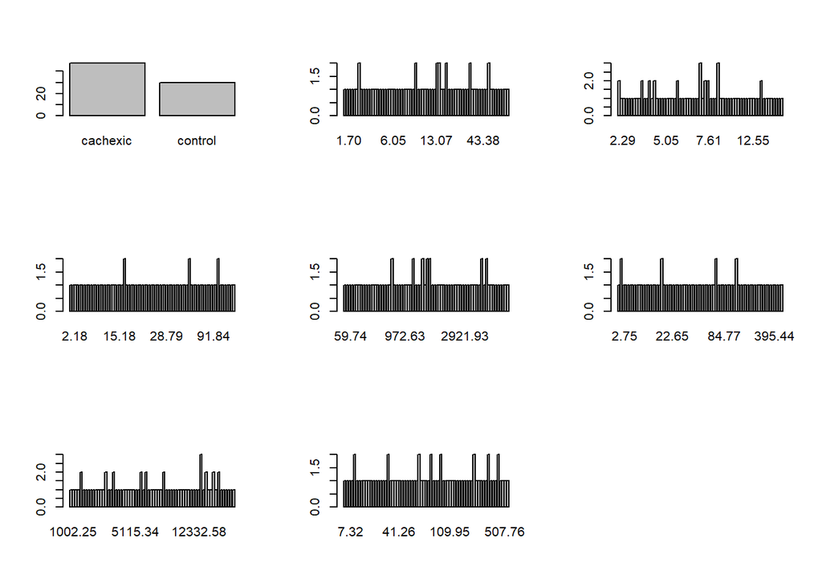

```r
f<- function(x){
  ifelse (is.numeric(x),
          hist(x, breaks=5),
          barplot(table(x))
  )
}
par(mfrow=c(3,3))
apply(datos_estudio,2,f)
```

Análisis de los PCA: Cáclulo de matriz de varianza y correlaciones entre variables.

```r
datosnum <- datos_estudio[sapply(datos_estudio, is.numeric)]
datosnum <- scale(datosnum, center = TRUE, scale=FALSE)
apply(datosnum,2, mean)
```

```
## X3.Hydroxybutyrate            Acetone          Carnitine            Citrate
##       9.665339e-16       7.821857e-16       8.680601e-16      -9.138722e-14
##           Creatine         Creatinine            Lactate
##       1.703003e-15      -6.499274e-13       3.259478e-16
```

```r
n<- dim(datos_estudio)[1]
S<-cov(datosnum)*(n-1)/n
show(S)
```

```
##                    X3.Hydroxybutyrate    Acetone   Carnitine    Citrate
## X3.Hydroxybutyrate           677.4685   427.3044    620.0402   39865.76
## Acetone                      427.3044   543.2439    447.4368   28786.70
## Carnitine                    620.0402   447.4368   5396.7269   58061.53
## Citrate                    39865.7633 28786.6983  58061.5324 4633054.50
## Creatine                     620.5471  -105.2377   4355.6401   33836.24
## Creatinine                103627.6622 32323.2909 100661.3417 9156470.21
## Lactate                     3790.5667  2084.6163   2836.1088   52416.55
##                       Creatine  Creatinine    Lactate
## X3.Hydroxybutyrate    620.5471   103627.66   3790.567
## Acetone              -105.2377    32323.29   2084.616
## Carnitine            4355.6401   100661.34   2836.109
## Citrate             33836.2430  9156470.21  52416.545
## Creatine            73677.7407   234521.11   3158.188
## Creatinine         234521.1099 41414596.48 470068.289
## Lactate              3158.1876   470068.29 174442.000
```

```r
R<-cor(datosnum)
show(R)
```

```
##                    X3.Hydroxybutyrate     Acetone  Carnitine    Citrate
## X3.Hydroxybutyrate         1.00000000  0.70436117 0.32427249 0.71157686
## Acetone                    0.70436117  1.00000000 0.26131782 0.57380021
## Carnitine                  0.32427249  0.26131782 1.00000000 0.36718892
## Citrate                    0.71157686  0.57380021 0.36718892 1.00000000
## Creatine                   0.08783388 -0.01663435 0.21843318 0.05791356
## Creatinine                 0.61866340  0.21549709 0.21292212 0.66102467
## Lactate                    0.34868563  0.21414264 0.09243408 0.05830545
##                       Creatine Creatinine    Lactate
## X3.Hydroxybutyrate  0.08783388  0.6186634 0.34868563
## Acetone            -0.01663435  0.2154971 0.21414264
## Carnitine           0.21843318  0.2129221 0.09243408
## Citrate             0.05791356  0.6610247 0.05830545
## Creatine            1.00000000  0.1342570 0.02785763
## Creatinine          0.13425704  1.0000000 0.17488748
## Lactate             0.02785763  0.1748875 1.00000000
```

X3.Hydroxybutyrate y Acetona tiene un alto nivel de correlación entre ambas. Creatine con Acetone y Lactate con Creatine no presentan una correlación imporante.

PCAs

```r
EIG <- eigen(S)
show(EIG)
```

```
## eigen() decomposition
## $values
## [1] 4.357492e+07 2.481968e+06 1.680939e+05 7.245850e+04 4.387274e+03
## [6] 4.516335e+02 1.124756e+02
##
## $vectors
##               [,1]         [,2]         [,3]         [,4]         [,5]
## [1,] -0.0025253308 -0.006053291  0.017712914 -0.002111101 -0.020537790
## [2,] -0.0008738129 -0.008294191  0.012995334  0.001880098 -0.012634176
## [3,] -0.0025551562 -0.013482316  0.015044468 -0.059375060 -0.997725191
## [4,] -0.2288962230 -0.973038210  0.020890854 -0.006242198  0.014666457
## [5,] -0.0054266785  0.008592476  0.001650884 -0.998182603  0.059309160
## [6,] -0.9733685494  0.228557571 -0.016126963  0.007161435 -0.001264002
## [7,] -0.0108197762  0.024434405  0.999295655  0.002801982  0.015124175
##               [,6]          [,7]
## [1,] -0.6455370872  0.7632161192
## [2,] -0.7630140251 -0.6460712069
## [3,]  0.0233342996 -0.0077406749
## [4,]  0.0106071879  0.0003894198
## [5,] -0.0014708599 -0.0023972414
## [6,] -0.0004187289 -0.0014020181
## [7,]  0.0207876367 -0.0050367514
```

```r
eigenVecs1 <- EIG$vectors
PCAS1 <- datosnum %*% eigenVecs1
head(PCAS1)
```

```
##                   [,1]       [,2]      [,3]      [,4]         [,5]        [,6]
## PIF_178      -7880.319   327.7705 -141.8491 -36.02949 -197.9547082   -4.951580
## PIF_087      -7002.719  1255.9738  105.1314 -40.76888  -63.6150984   -7.651291
## PIF_090     -15124.071  4974.9613  306.1016  30.98225    1.7953447    6.035879
## NETL_005_V1 -14503.952 -8294.2474  258.5259  49.32962   -1.1424496 -124.699269
## PIF_115       2191.717   978.6304 3484.7429  23.46122   -0.5157773   -1.193842
## PIF_110      -6695.453  1855.9196 -162.7298 -21.34653    2.6134181  -15.991436
##                   [,7]
## PIF_178      16.209281
## PIF_087       5.015124
## PIF_090     -33.514352
## NETL_005_V1 -23.110573
## PIF_115       5.234495
## PIF_110      -3.934483
```

Los valores de creatinina son muy altos, lo que indica que tiene una gran influencia sobre el PCA 1.

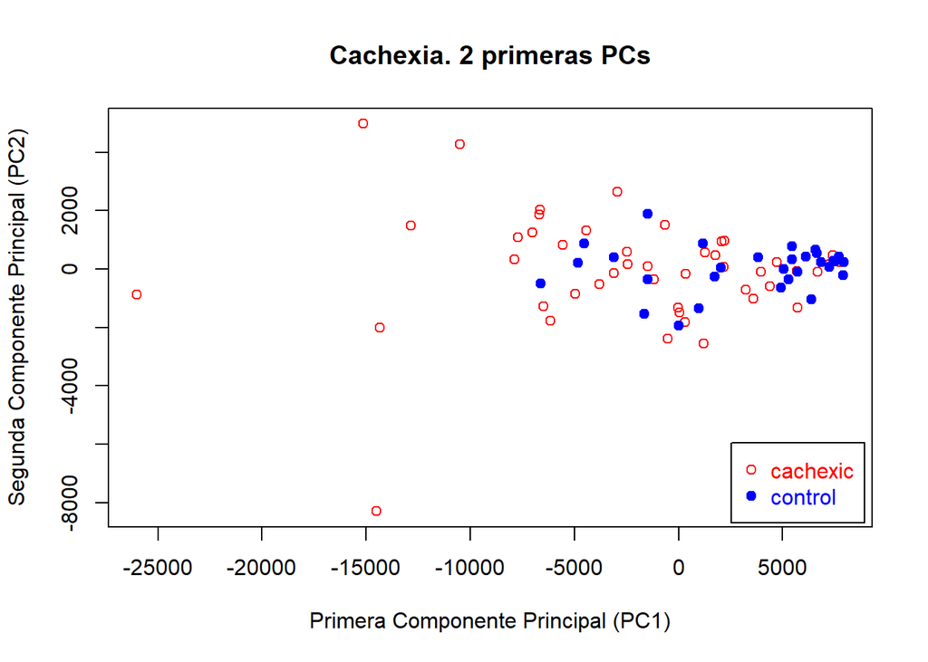

```r
xlabel <- "Primera Componente Principal (PC1)"
ylabel <- "Segunda Componente Principal (PC2)"

par(mfrow=c(1,1))

bgSurv <- colSurv <- ifelse(datos$Muscle.loss == "cachexic", "red", "blue")
pchSurv <- ifelse(datos$Muscle.loss == "cachexic", 1, 19)

plot(PCAS1[, 1], PCAS1[, 2], main = "Cachexia. 2 primeras PCs",
     xlab = xlabel, ylab = ylabel,
     pch = pchSurv, col = colSurv, bg = bgSurv)

legend("bottomright", inset = c(0.01, 0.01), cex = 1,
       bty = "y", legend = c("cachexic", "control"),
       text.col = c("red", "blue"),
       col = c("red", "blue"),
       pt.bg = c("red", "blue"),
       pch = c(1, 19))
```

## Identificación de otros valores de interés

Vamos a proceder a identificar otros biomarcadores de interés

```r
t_tests <- datos %>%
  summarise(across(where(is.numeric),
                   ~t.test(. ~ Muscle.loss)$p.value))
print(t_tests)
```

```
##   X1.6.Anhydro.beta.D.glucose X1.Methylnicotinamide X2.Aminobutyrate
## 1                  0.03531943             0.9435367      0.007859048
##   X2.Hydroxyisobutyrate X2.Oxoglutarate X3.Aminoisobutyrate X3.Hydroxybutyrate
## 1           0.004893295       0.1585788           0.1021946        0.000133459
##   X3.Hydroxyisovalerate X3.Indoxylsulfate X4.Hydroxyphenylacetate     Acetate
## 1           0.003458034       0.004849645               0.5272919 0.001740727
##     Acetone     Adipate      Alanine  Asparagine    Betaine  Carnitine
## 1 0.2731685 0.007515595 0.0002960803 0.003566603 0.00217492 0.03192506
##       Citrate   Creatine   Creatinine Dimethylamine Ethanolamine     Formate
## 1 0.005098507 0.01984702 0.0001369605   5.34899e-05   0.02011237 0.004909304
##        Fucose   Fumarate     Glucose  Glutamine    Glycine  Glycolate
## 1 0.001863466 0.02620524 0.009239445 0.00033916 0.01304117 0.04940718
##   Guanidoacetate Hippurate   Histidine Hypoxanthine Isoleucine    Lactate
## 1      0.1165822 0.0101546 0.004541154    0.2421171  0.1087749 0.05733204
##        Leucine    Lysine Methylamine Methylguanidine N.N.Dimethylglycine
## 1 2.662822e-05 0.3347563 0.001496975        0.202775        2.114015e-05
##   O.Acetylcarnitine Pantothenate Pyroglutamate    Pyruvate  Quinolinate
## 1        0.02418993    0.6085017  7.289814e-05 0.007357362 2.708732e-05
##         Serine   Succinate    Sucrose  Tartrate    Taurine   Threonine
## 1 0.0008173888 0.003676506 0.06558505 0.3758724 0.01418748 0.001183249
##   Trigonelline Trimethylamine.N.oxide   Tryptophan    Tyrosine    Uracil
## 1  0.003219917             0.01586788 0.0008885986 0.004456642 0.5386741
##         Valine    Xylose cis.Aconitate myo.Inositol trans.Aconitate
## 1 1.574212e-05 0.1335317  0.0006190184 0.0003611776      0.01953314
##   pi.Methylhistidine tau.Methylhistidine
## 1         0.09958934          0.01710741
```

Las variables con p-valores bajos indican diferencias significativas entre los grupos, lo cual podría señalar importancia en la cachexia.

```r
datos_estandarizados <- as.data.frame(scale(datos[ , -which(names(datos) %in% c("Patient.ID", "Muscle.loss"))]))
datos_estandarizados$Muscle.loss <- as.factor(datos$Muscle.loss)
datos_estandarizados <- na.omit(datos_estandarizados)
modelo_logistico <- glm(Muscle.loss ~ ., data = datos_estandarizados, family = "binomial")
summary(modelo_logistico)
```

```
##
## Call:
## glm(formula = Muscle.loss ~ ., family = "binomial", data = datos_estandarizados)
##
## Coefficients:
##                               Estimate Std. Error z value Pr(>|z|)
## (Intercept)                 -1.454e+01  8.876e+04       0        1
## X1.6.Anhydro.beta.D.glucose -5.481e+00  5.508e+05       0        1
## X1.Methylnicotinamide        8.692e+01  1.923e+06       0        1
## X2.Aminobutyrate            -2.993e+01  1.659e+06       0        1
## X2.Hydroxyisobutyrate        1.667e-01  2.097e+06       0        1
## X2.Oxoglutarate             -1.733e+02  2.114e+06       0        1
## X3.Aminoisobutyrate         -5.023e+01  1.232e+06       0        1
## X3.Hydroxybutyrate           2.313e+02  5.011e+06       0        1
## X3.Hydroxyisovalerate       -1.371e+02  5.210e+05       0        1
## X3.Indoxylsulfate           -5.519e+01  1.269e+06       0        1
## X4.Hydroxyphenylacetate      8.105e+01  7.312e+05       0        1
## Acetate                     -7.397e+01  8.845e+05       0        1
## Acetone                     -1.321e+02  1.363e+06       0        1
## Adipate                      4.296e+01  8.139e+05       0        1
## Alanine                      2.262e+01  1.256e+06       0        1
## Asparagine                  -9.753e+01  2.197e+06       0        1
## Betaine                      3.812e+01  2.020e+06       0        1
## Carnitine                   -1.778e+01  5.882e+05       0        1
## Citrate                     -1.899e+01  6.701e+05       0        1
## Creatine                     1.411e+01  2.801e+05       0        1
## Creatinine                   9.665e+01  2.305e+06       0        1
## Dimethylamine               -7.600e+01  4.132e+05       0        1
## Ethanolamine                 3.214e+01  2.964e+06       0        1
## Formate                     -5.587e+01  2.108e+06       0        1
## Fucose                      -1.298e+02  9.607e+05       0        1
## Fumarate                     1.149e+02  2.839e+06       0        1
## Glucose                     -2.904e+01  8.398e+05       0        1
## Glutamine                   -1.229e+02  1.817e+06       0        1
## Glycine                      5.614e+01  8.142e+05       0        1
## Glycolate                    1.889e+01  1.140e+06       0        1
## Guanidoacetate               1.284e+01  3.754e+05       0        1
## Hippurate                   -1.646e+00  5.821e+05       0        1
## Histidine                   -5.636e+01  2.189e+06       0        1
## Hypoxanthine                -1.038e+02  1.222e+06       0        1
```

[output cut: 23 more lines]

```
## Valine                       7.175e+01  2.789e+06       0        1
## Xylose                      -6.636e+00  1.286e+06       0        1
## cis.Aconitate                1.074e+02  1.391e+06       0        1
## myo.Inositol                -1.831e+01  1.497e+06       0        1
## trans.Aconitate              2.307e+01  8.176e+05       0        1
## pi.Methylhistidine          -6.283e+01  3.208e+05       0        1
## tau.Methylhistidine          5.259e+01  7.032e+05       0        1
##
## (Dispersion parameter for binomial family taken to be 1)
##
##     Null deviance: 1.0296e+02  on 76  degrees of freedom
## Residual deviance: 1.2833e-09  on 13  degrees of freedom
## AIC: 128
##
## Number of Fisher Scoring iterations: 25
```

Identificación PCAs

```r
datos_num <- datos %>% select(where(is.numeric))
datos_escala <- scale(datos_num)
pca <- prcomp(datos_escala, center = TRUE, scale. = TRUE)
summary(pca)
```

```
## Importance of components:
##                           PC1    PC2     PC3     PC4     PC5    PC6     PC7
## Standard deviation     5.0467 2.2701 1.83311 1.74728 1.65906 1.6130 1.47304
## Proportion of Variance 0.4043 0.0818 0.05334 0.04846 0.04369 0.0413 0.03444
## Cumulative Proportion  0.4043 0.4861 0.53941 0.58787 0.63156 0.6729 0.70730
##                            PC8     PC9    PC10   PC11    PC12    PC13   PC14
## Standard deviation     1.36403 1.24275 1.20650 1.1584 1.05503 1.03620 0.9914
## Proportion of Variance 0.02953 0.02451 0.02311 0.0213 0.01767 0.01704 0.0156
## Cumulative Proportion  0.73683 0.76135 0.78445 0.8057 0.82342 0.84046 0.8561
##                           PC15    PC16    PC17    PC18   PC19    PC20    PC21
## Standard deviation     0.96773 0.89551 0.86788 0.83041 0.8133 0.73918 0.72112
## Proportion of Variance 0.01487 0.01273 0.01196 0.01095 0.0105 0.00867 0.00825
## Cumulative Proportion  0.87093 0.88366 0.89562 0.90656 0.9171 0.92573 0.93399
##                           PC22    PC23    PC24   PC25   PC26    PC27    PC28
## Standard deviation     0.71053 0.64606 0.63389 0.5830 0.5442 0.50539 0.48743
## Proportion of Variance 0.00801 0.00663 0.00638 0.0054 0.0047 0.00405 0.00377
## Cumulative Proportion  0.94200 0.94863 0.95500 0.9604 0.9651 0.96916 0.97293
##                           PC29    PC30    PC31    PC32    PC33    PC34    PC35
## Standard deviation     0.42674 0.42427 0.41483 0.38653 0.35092 0.32424 0.31646
## Proportion of Variance 0.00289 0.00286 0.00273 0.00237 0.00195 0.00167 0.00159
## Cumulative Proportion  0.97582 0.97867 0.98141 0.98378 0.98573 0.98740 0.98899
##                          PC36    PC37    PC38    PC39    PC40    PC41    PC42
## Standard deviation     0.2867 0.28435 0.26060 0.25353 0.24800 0.21896 0.19537
## Proportion of Variance 0.0013 0.00128 0.00108 0.00102 0.00098 0.00076 0.00061
## Cumulative Proportion  0.9903 0.99158 0.99266 0.99368 0.99465 0.99541 0.99602
##                           PC43   PC44    PC45   PC46    PC47   PC48    PC49
## Standard deviation     0.18914 0.1767 0.16864 0.1580 0.15287 0.1380 0.13101
## Proportion of Variance 0.00057 0.0005 0.00045 0.0004 0.00037 0.0003 0.00027
## Cumulative Proportion  0.99659 0.9971 0.99753 0.9979 0.99830 0.9986 0.99888
##                           PC50    PC51    PC52    PC53    PC54    PC55    PC56
## Standard deviation     0.10759 0.10374 0.09853 0.08760 0.08258 0.08049 0.06927
## Proportion of Variance 0.00018 0.00017 0.00015 0.00012 0.00011 0.00010 0.00008
## Cumulative Proportion  0.99906 0.99923 0.99939 0.99951 0.99962 0.99972 0.99979
##                           PC57    PC58    PC59    PC60    PC61    PC62    PC63
## Standard deviation     0.05937 0.05673 0.05088 0.04001 0.02972 0.02789 0.01876
## Proportion of Variance 0.00006 0.00005 0.00004 0.00003 0.00001 0.00001 0.00001
## Cumulative Proportion  0.99985 0.99990 0.99994 0.99997 0.99998 0.99999 1.00000
```

# Discusión y limitaciones y conclusiones del estudio

Uno de los primeros problemas que se han planteado a la hora de realizar el trabajo es la gran cantidad de variables que podíamos estudiar, teniendo que seleccionar previamente aquellos biomarcadores que pensábamos que estaban relacionados directamente con la enfermedad.

En una primera fase, hemos dejando a un lado, seguramente, otros factores igual o más importantes para el análisis de la enfermedad.Por ello, hemos realizado un análisis PCA y estudio del p-valor con t de student para identificar otro factor determinante.

# Anexo I: Base de datos

```r
url <- "https://raw.githubusercontent.com/nutrimetabolomics/metaboData/refs/heads/main/Datasets/2024-Cachexia/human_cachexia.csv"
datos <- read.csv(url)
```

```r
library(skimr)
skim(datos)
```

Data summary

| Name | datos |
| --- | --- |
| Number of rows | 77 |
| Number of columns | 65 |
| _______________________ |  |
| Column type frequency: |  |
| character | 2 |
| numeric | 63 |
| ________________________ |  |
| Group variables | None |

**Variable type: character**

| skim_variable | n_missing | complete_rate | min | max | empty | n_unique | whitespace |
| --- | --- | --- | --- | --- | --- | --- | --- |
| Patient.ID | 0 | 1 | 7 | 12 | 0 | 77 | 0 |
| Muscle.loss | 0 | 1 | 7 | 8 | 0 | 2 | 0 |

**Variable type: numeric**

| skim_variable | n_missing | complete_rate | mean | sd | p0 | p25 | p50 | p75 | p100 | hist |
| --- | --- | --- | --- | --- | --- | --- | --- | --- | --- | --- |
| X1.6.Anhydro.beta.D.glucose | 0 | 1 | 105.63 | 130.03 | 4.71 | 28.79 | 45.60 | 141.17 | 685.40 | ▇▂▁▁▁ |
| X1.Methylnicotinamide | 0 | 1 | 71.57 | 133.19 | 6.42 | 15.80 | 36.60 | 73.70 | 1032.77 | ▇▁▁▁▁ |
| X2.Aminobutyrate | 0 | 1 | 18.16 | 27.61 | 1.28 | 5.26 | 10.49 | 19.49 | 172.43 | ▇▁▁▁▁ |
| X2.Hydroxyisobutyrate | 0 | 1 | 37.25 | 23.96 | 4.85 | 15.80 | 32.46 | 54.60 | 93.69 | ▇▅▅▃▂ |
| X2.Oxoglutarate | 0 | 1 | 145.09 | 342.52 | 5.53 | 22.42 | 55.15 | 92.76 | 2465.13 | ▇▁▁▁▁ |
| X3.Aminoisobutyrate | 0 | 1 | 76.76 | 191.01 | 2.61 | 11.70 | 22.65 | 56.26 | 1480.30 | ▇▁▁▁▁ |
| X3.Hydroxybutyrate | 0 | 1 | 21.72 | 26.20 | 1.70 | 5.99 | 11.70 | 29.96 | 175.91 | ▇▂▁▁▁ |
| X3.Hydroxyisovalerate | 0 | 1 | 21.65 | 24.95 | 0.92 | 5.26 | 12.55 | 30.27 | 164.02 | ▇▂▁▁▁ |
| X3.Indoxylsulfate | 0 | 1 | 218.88 | 196.87 | 27.66 | 82.27 | 144.03 | 333.62 | 1043.15 | ▇▂▁▁▁ |
| X4.Hydroxyphenylacetate | 0 | 1 | 112.02 | 120.81 | 15.49 | 41.68 | 70.11 | 145.47 | 796.32 | ▇▁▁▁▁ |
| Acetate | 0 | 1 | 66.14 | 79.21 | 3.49 | 16.28 | 39.65 | 86.49 | 411.58 | ▇▂▁▁▁ |
| Acetone | 0 | 1 | 11.43 | 23.46 | 2.29 | 4.95 | 7.10 | 10.49 | 206.44 | ▇▁▁▁▁ |
| Adipate | 0 | 1 | 24.76 | 50.43 | 1.55 | 6.11 | 10.18 | 19.11 | 327.01 | ▇▁▁▁▁ |
| Alanine | 0 | 1 | 273.56 | 256.99 | 16.78 | 78.26 | 194.42 | 399.41 | 1312.91 | ▇▃▁▁▁ |
| Asparagine | 0 | 1 | 62.28 | 53.95 | 6.69 | 20.49 | 42.10 | 89.12 | 273.14 | ▇▃▂▁▁ |
| Betaine | 0 | 1 | 90.32 | 82.72 | 2.29 | 28.79 | 64.72 | 127.74 | 391.51 | ▇▃▁▁▁ |
| Carnitine | 0 | 1 | 52.09 | 73.94 | 2.18 | 14.44 | 23.81 | 60.95 | 487.85 | ▇▁▁▁▁ |
| Citrate | 0 | 1 | 2235.35 | 2166.57 | 59.74 | 788.40 | 1790.05 | 3071.74 | 13629.61 | ▇▃▁▁▁ |
| Creatine | 0 | 1 | 126.83 | 273.22 | 2.75 | 17.64 | 44.26 | 117.92 | 1863.11 | ▇▁▁▁▁ |
| Creatinine | 0 | 1 | 8733.97 | 6477.62 | 1002.25 | 3498.19 | 7631.20 | 12332.58 | 33860.35 | ▇▅▂▁▁ |
| Dimethylamine | 0 | 1 | 358.17 | 307.82 | 41.26 | 142.59 | 304.90 | 454.86 | 1556.20 | ▇▃▁▁▁ |
| Ethanolamine | 0 | 1 | 276.26 | 251.78 | 16.12 | 86.49 | 204.38 | 407.48 | 1436.55 | ▇▃▁▁▁ |
| Formate | 0 | 1 | 147.40 | 187.18 | 6.42 | 53.52 | 95.58 | 167.34 | 1480.30 | ▇▁▁▁▁ |
| Fucose | 0 | 1 | 88.67 | 80.66 | 5.70 | 29.37 | 61.56 | 123.97 | 407.48 | ▇▃▂▁▁ |
| Fumarate | 0 | 1 | 8.44 | 14.47 | 0.79 | 2.23 | 4.10 | 7.85 | 96.54 | ▇▁▁▁▁ |
| Glucose | 0 | 1 | 559.84 | 1386.94 | 26.84 | 80.64 | 210.61 | 407.48 | 8690.62 | ▇▁▁▁▁ |
| Glutamine | 0 | 1 | 306.87 | 290.97 | 23.34 | 113.30 | 225.88 | 445.86 | 1685.81 | ▇▃▁▁▁ |
| Glycine | 0 | 1 | 880.72 | 949.69 | 38.09 | 262.43 | 528.48 | 1096.63 | 5064.45 | ▇▂▁▁▁ |
| Glycolate | 0 | 1 | 187.99 | 180.42 | 5.42 | 50.91 | 130.32 | 267.74 | 720.54 | ▇▃▁▁▁ |
| Guanidoacetate | 0 | 1 | 86.37 | 83.10 | 7.03 | 33.78 | 64.72 | 108.85 | 561.16 | ▇▂▁▁▁ |
| Hippurate | 0 | 1 | 2286.84 | 2870.32 | 92.76 | 492.75 | 1224.15 | 2921.93 | 19341.34 | ▇▂▁▁▁ |
| Histidine | 0 | 1 | 292.64 | 312.76 | 14.15 | 66.69 | 174.16 | 419.89 | 1863.11 | ▇▂▁▁▁ |
| Hypoxanthine | 0 | 1 | 61.10 | 57.53 | 3.78 | 20.70 | 40.04 | 83.93 | 265.07 | ▇▃▁▁▁ |
| Isoleucine | 0 | 1 | 8.71 | 6.94 | 1.79 | 3.90 | 7.17 | 11.25 | 40.04 | ▇▃▁▁▁ |
| Lactate | 0 | 1 | 158.46 | 420.40 | 7.32 | 35.52 | 81.45 | 139.77 | 3640.95 | ▇▁▁▁▁ |
| Leucine | 0 | 1 | 24.36 | 21.52 | 2.51 | 9.12 | 19.11 | 31.19 | 103.54 | ▇▃▁▁▁ |
| Lysine | 0 | 1 | 108.79 | 126.66 | 10.49 | 30.27 | 69.41 | 121.51 | 788.40 | ▇▁▁▁▁ |
| Methylamine | 0 | 1 | 17.38 | 13.92 | 1.51 | 5.26 | 14.73 | 24.05 | 52.46 | ▇▅▃▁▂ |
| Methylguanidine | 0 | 1 | 15.32 | 19.85 | 1.70 | 4.26 | 7.85 | 19.30 | 141.17 | ▇▂▁▁▁ |
| N.N.Dimethylglycine | 0 | 1 | 26.35 | 24.54 | 0.79 | 7.03 | 21.98 | 40.04 | 120.30 | ▇▃▁▁▁ |
| O.Acetylcarnitine | 0 | 1 | 19.73 | 34.33 | 1.23 | 3.94 | 11.47 | 20.91 | 254.68 | ▇▁▁▁▁ |
| Pantothenate | 0 | 1 | 44.88 | 86.77 | 2.59 | 11.13 | 22.65 | 41.26 | 692.29 | ▇▁▁▁▁ |
| Pyroglutamate | 0 | 1 | 211.45 | 190.95 | 21.33 | 68.72 | 157.59 | 301.87 | 1064.22 | ▇▅▁▁▁ |
| Pyruvate | 0 | 1 | 21.29 | 25.97 | 0.90 | 4.85 | 13.46 | 29.08 | 184.93 | ▇▂▁▁▁ |
| Quinolinate | 0 | 1 | 66.44 | 51.35 | 5.21 | 26.58 | 51.42 | 87.36 | 259.82 | ▇▃▁▁▁ |
| Serine | 0 | 1 | 197.69 | 185.79 | 16.12 | 83.10 | 142.59 | 270.43 | 1248.88 | ▇▂▁▁▁ |
| Succinate | 0 | 1 | 60.23 | 85.16 | 1.72 | 8.58 | 30.88 | 74.44 | 589.93 | ▇▁▁▁▁ |
| Sucrose | 0 | 1 | 113.23 | 259.07 | 6.49 | 19.30 | 40.85 | 94.63 | 2079.74 | ▇▁▁▁▁ |
| Tartrate | 0 | 1 | 40.00 | 103.48 | 2.20 | 6.89 | 12.94 | 25.79 | 837.15 | ▇▁▁▁▁ |
| Taurine | 0 | 1 | 525.12 | 673.85 | 17.81 | 99.48 | 249.64 | 665.14 | 4272.69 | ▇▂▁▁▁ |
| Threonine | 0 | 1 | 95.36 | 87.10 | 8.25 | 31.82 | 64.07 | 137.00 | 450.34 | ▇▃▁▁▁ |
| Trigonelline | 0 | 1 | 270.44 | 398.09 | 10.07 | 53.52 | 114.43 | 340.36 | 2252.96 | ▇▁▁▁▁ |
| Trimethylamine.N.oxide | 0 | 1 | 652.16 | 910.15 | 55.70 | 175.91 | 383.75 | 735.10 | 5486.25 | ▇▁▁▁▁ |
| Tryptophan | 0 | 1 | 66.24 | 56.33 | 8.67 | 21.33 | 46.99 | 96.54 | 259.82 | ▇▅▁▁▁ |
| Tyrosine | 0 | 1 | 81.76 | 83.25 | 4.22 | 23.57 | 60.34 | 113.30 | 539.15 | ▇▂▁▁▁ |
| Uracil | 0 | 1 | 35.56 | 35.00 | 3.10 | 11.94 | 27.39 | 44.26 | 179.47 | ▇▂▁▁▁ |
| Valine | 0 | 1 | 35.67 | 29.70 | 4.10 | 12.18 | 33.12 | 50.40 | 160.77 | ▇▅▁▁▁ |
| Xylose | 0 | 1 | 100.93 | 250.22 | 10.07 | 29.96 | 50.40 | 89.12 | 2164.62 | ▇▁▁▁▁ |
| cis.Aconitate | 0 | 1 | 204.22 | 278.14 | 12.94 | 36.23 | 129.02 | 254.68 | 1863.11 | ▇▁▁▁▁ |
| myo.Inositol | 0 | 1 | 135.40 | 170.27 | 11.59 | 30.27 | 78.26 | 167.34 | 854.06 | ▇▁▁▁▁ |
| trans.Aconitate | 0 | 1 | 40.63 | 39.57 | 4.90 | 12.43 | 26.84 | 57.40 | 217.02 | ▇▂▁▁▁ |
| pi.Methylhistidine | 0 | 1 | 370.29 | 530.69 | 11.36 | 67.36 | 162.39 | 387.61 | 2697.28 | ▇▁▁▁▁ |
| tau.Methylhistidine | 0 | 1 | 89.69 | 77.24 | 8.00 | 27.39 | 68.72 | 130.32 | 317.35 | ▇▅▂▁▁ |